# Practical Machine Learning Course Project

Ken Cannon

November 5, 2016

## Model Building

In the following code, I will use various datasets to build prediction models to predict the manner in which an exercise was done, corresponding to the “classe” variable in the dataset of individuals doing 10 reptitions of the Unilateral Dumbbell Biceps Curl in five different manners: A (correct) and B through E (incorrect).

The dataset has already been split into a training and a testing dataset. I load the data, as well as associated libraries necessary for analysis (code not shown).

The following displays a distribution of the main variable of interest. We can see that the exercise was done correctly the most of any of the five variables.

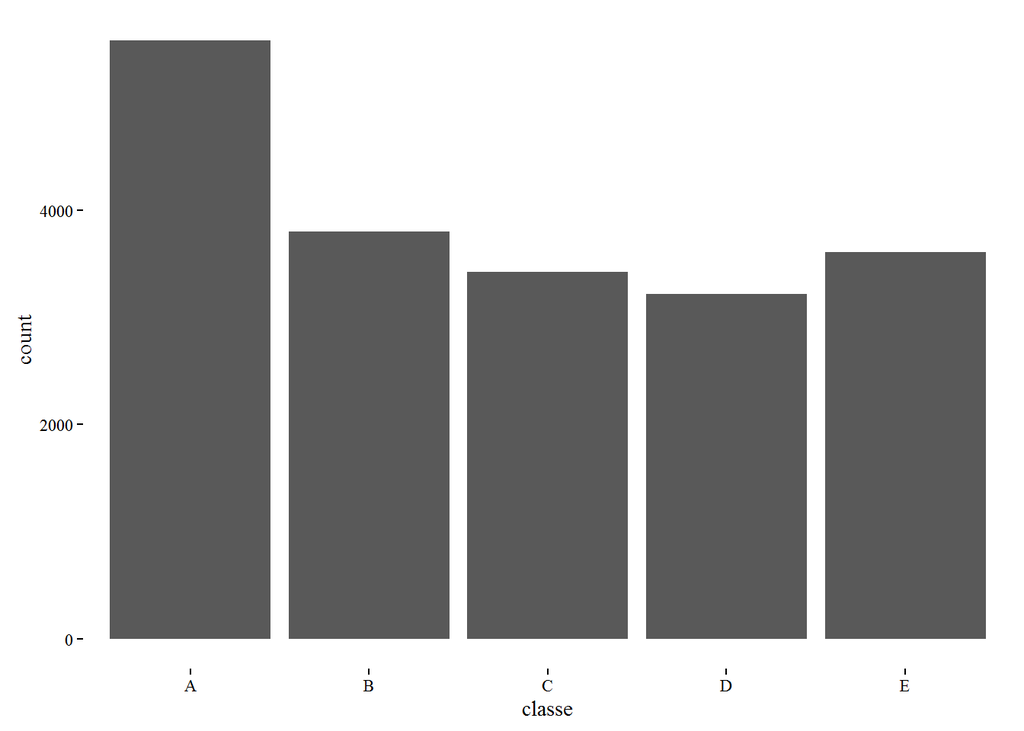

```r
#Display distribution of classe variable
barClasse <- ggplot(training, aes(x = classe)) + geom_bar() + theme_tufte()
barClasse
```

I now exclude variables with mostly NAs or blank values from the training and testing sets (to preclude their use as explanatory variables).

```r
# Create subset of columns without mostly NA values
trainingsub <- training[, c(8:11, 37:49, 60:68, 84:86, 102, 113:124, 140, 151:160)]
testingsub <- testing[, c(8:11, 37:49, 60:68, 84:86, 102, 113:124, 140, 151:160)]
```

Because there are approximately 160 variables in the dataset in total, I create principal components from the subsetted dataset’s numeric variables as a dimension reduction technique, which will be used in a few subsequent analyses to determine if fewer explanatory variables could be used to explain the outcome variable.

```r
#Create principal components from numeric explanatory variables, excluding variables
#on class
nums <- sapply(trainingsub, is.numeric)
trainingsubnums <- trainingsub[, nums]
preProc <- preProcess(trainingsub[,-53], method = "pca")
preProc
```

```
## Created from 19622 samples and 52 variables
##
## Pre-processing:
##   - centered (52)
##   - ignored (0)
##   - principal component signal extraction (52)
##   - scaled (52)
##
## PCA needed 25 components to capture 95 percent of the variance
```

```r
#Predict using classification and regression trees, using PCA subset
trainPC <- predict(preProc, trainingsub[,-53])
modelFit <- train(classe ~ ., method = "rpart", data = trainingsub)
modelFit
```

```
## CART
##
## 19622 samples
##    52 predictor
##     5 classes: 'A', 'B', 'C', 'D', 'E'
##
## No pre-processing
## Resampling: Bootstrapped (25 reps)
## Summary of sample sizes: 19622, 19622, 19622, 19622, 19622, 19622, ...
## Resampling results across tuning parameters:
##
##   cp          Accuracy   Kappa
##   0.03567868  0.5022899  0.34976875
##   0.05998671  0.4166208  0.21023233
##   0.11515454  0.3321434  0.07435257
##
## Accuracy was used to select the optimal model using  the largest value.
## The final value used for the model was cp = 0.03567868.
```

The second model uses linear discriminant analysis of the subsetted variables.

```r
#Predict using linear discriminant analysis
modelFit2 <- train(classe ~ ., method = "lda", data = trainingsub)
modelFit2
```

```
## Linear Discriminant Analysis
##
## 19622 samples
##    52 predictor
##     5 classes: 'A', 'B', 'C', 'D', 'E'
##
## No pre-processing
## Resampling: Bootstrapped (25 reps)
## Summary of sample sizes: 19622, 19622, 19622, 19622, 19622, 19622, ...
## Resampling results:
##
##   Accuracy  Kappa
##   0.700967  0.6214564
##
##
```

The third model uses quadratic discriminant analysis on the subsetted variables.

```r
#predict using quadratic discriminant analysis
modelFit3 <- train(classe ~ ., method = "qda", data = trainingsub)
modelFit3
```

```
## Quadratic Discriminant Analysis
##
## 19622 samples
##    52 predictor
##     5 classes: 'A', 'B', 'C', 'D', 'E'
##
## No pre-processing
## Resampling: Bootstrapped (25 reps)
## Summary of sample sizes: 19622, 19622, 19622, 19622, 19622, 19622, ...
## Resampling results:
##
##   Accuracy   Kappa
##   0.8944312  0.8665255
##
##
```

The fourth model uses a CART model without the PCA subsetted variables.

```r
#Predict using CART, without PCAs
modelFit4 <- train(classe ~ ., method = "rpart", data = trainingsub)
modelFit4
```

```
## CART
##
## 19622 samples
##    52 predictor
##     5 classes: 'A', 'B', 'C', 'D', 'E'
##
## No pre-processing
## Resampling: Bootstrapped (25 reps)
## Summary of sample sizes: 19622, 19622, 19622, 19622, 19622, 19622, ...
## Resampling results across tuning parameters:
##
##   cp          Accuracy   Kappa
##   0.03567868  0.5016156  0.34830995
##   0.05998671  0.4493797  0.26343626
##   0.11515454  0.3303729  0.06942853
##
## Accuracy was used to select the optimal model using  the largest value.
## The final value used for the model was cp = 0.03567868.
```

## Cross Validation

```r
numstest <- sapply(testingsub, is.numeric)
testingsubnums <- testingsub[,numstest]

preProcTest <- preProcess(testingsub[,-53], method = "pca")
preProcTest
```

```
## Created from 20 samples and 52 variables
##
## Pre-processing:
##   - centered (52)
##   - ignored (0)
##   - principal component signal extraction (52)
##   - scaled (52)
##
## PCA needed 12 components to capture 95 percent of the variance
```

```r
testPC <- predict(preProcTest, testingsub[,-53])
predict1 <- predict(modelFit, newdata= testingsub[,-53])
predict1
```

```
##  [1] C A C A A C C A A A C C C A C A A A A C
## Levels: A B C D E
```

```r
predict2 <- predict(modelFit2, newdata = testingsub[,-53])
predict2
```

```
##  [1] B A B C C E D D A A D A B A E A A B B B
## Levels: A B C D E
```

```r
predict3 <- predict(modelFit3, newdata =testingsub[,-53])
predict3
```

```
##  [1] A A B A A E D B A A B C B A E E A B B B
## Levels: A B C D E
```

```r
predict4 <- predict(modelFit4, newdata =testingsub[,-53])
predict4
```

```
##  [1] C A C A A C C A A A C C C A C A A A A C
## Levels: A B C D E
```

## Expected Out-of-Sample Error

```r
#Model 1
table(trainingsub$classe, predict(modelFit, trainingsub))
```

```
##
##        A    B    C    D    E
##   A 5080   81  405    0   14
##   B 1581 1286  930    0    0
##   C 1587  108 1727    0    0
##   D 1449  568 1199    0    0
##   E  524  486  966    0 1631
```

```r
a = sum(predict(modelFit, trainingsub) == trainingsub$classe)/nrow(trainingsub)
a
```

```
## [1] 0.4955662
```

```r
#Model 2
table(trainingsub$classe, predict(modelFit2, trainingsub))
```

```
##
##        A    B    C    D    E
##   A 4568  121  444  429   18
##   B  586 2429  455  148  179
##   C  341  333 2254  411   83
##   D  191  130  379 2383  133
##   E  133  611  323  344 2196
```

```r
b = sum(predict(modelFit2, trainingsub) == trainingsub$classe)/nrow(trainingsub)
b
```

```
## [1] 0.7048211
```

```r
#Model 3
table(trainingsub$classe, predict(modelFit3, trainingsub))
```

```
##
##        A    B    C    D    E
##   A 5184  207  100   78   11
##   B  190 3194  374   12   27
##   C    0  155 3243   13   11
##   D    5   13  424 2741   33
##   E    0  109  144   85 3269
```

```r
c = sum(predict(modelFit3, trainingsub) == trainingsub$classe)/nrow(trainingsub)
c
```

```
## [1] 0.8985323
```

```r
#Model 4
table(trainingsub$classe, predict(modelFit4, trainingsub))
```

```
##
##        A    B    C    D    E
##   A 5080   81  405    0   14
##   B 1581 1286  930    0    0
##   C 1587  108 1727    0    0
##   D 1449  568 1199    0    0
##   E  524  486  966    0 1631
```

```r
d = sum(predict(modelFit4, trainingsub) == trainingsub$classe)/nrow(trainingsub)
d
```

```
## [1] 0.4955662
```